# **EDA, Feature Engineering, Hypothesis Testing, and Classification on Heart Failure Prediction Dataset**

### **Introduction**

##### What are cardiovascular diseases?

Cardiovascular diseases (CVDs) are a group of disorders of the heart and blood vessels. They include:

- coronary heart disease – a disease of the blood vessels supplying the heart muscle;
- cerebrovascular disease – a disease of the blood vessels supplying the brain;
- peripheral arterial disease – a disease of blood vessels supplying the arms and legs;
- rheumatic heart disease – damage to the heart muscle and heart valves from rheumatic fever, caused by streptococcal bacteria;
- congenital heart disease – birth defects that affect the normal development and functioning of the heart caused by malformations of the heart structure from birth; and deep vein thrombosis and pulmonary embolism – blood clots in the leg veins, which can dislodge and move to the heart and lungs.

Heart attacks and strokes are usually acute events and are mainly caused by a blockage that prevents blood from flowing to the heart or brain. The most common reason for this is a build-up of fatty deposits on the inner walls of the blood vessels that supply the heart or brain. Strokes can be caused by bleeding from a blood vessel in the brain or from blood clots. (source))

### **Dataset Overview**

##### Feature Information

- Age: age of the patient [years]
- Sex: sex of the patient [M: Male, F: Female]
- ChestPainType: chest pain type [TA: Typical Angina, ATA: Atypical Angina, NAP: Non-Anginal Pain, ASY: Asymptomatic]
- RestingBP: resting blood pressure [mm Hg]
- Cholesterol: serum cholesterol [mm/dl]
- FastingBS: fasting blood sugar [1: if FastingBS > 120 mg/dl, 0: otherwise]
- RestingECG: resting electrocardiogram results [Normal: Normal, ST: having ST-T wave abnormality (T wave inversions and/or ST elevation or depression of > 0.05 mV), LVH: showing probable or definite left ventricular hypertrophy by Estes' criteria]
- MaxHR: maximum heart rate achieved [Numeric value between 60 and 202]
- ExerciseAngina: exercise-induced angina [Y: Yes, N: No]
- Oldpeak: oldpeak = ST [Numeric value measured in depression]
- ST_Slope: the slope of the peak exercise ST segment [Up: upsloping, Flat: flat, Down: downsloping]
- HeartDisease: output class [1: heart disease, 0: Normal]

##### Source

Dataset was taken from [Heart Failure Prediction Dataset](https://www.kaggle.com/fedesoriano/heart-failure-prediction)

### **Section 1: Setup, Load, and Clean**

```python
import os
data_path = ['data']
```

```python
## Import neccessary libraries to load data
import numpy as np
import pandas as pd
import warnings
warnings.filterwarnings('ignore')
```

```python
## Load in the Dataset
filepath = os.sep.join(
    data_path + ['heart.csv'])
df = pd.read_csv(filepath)
df.head()
```

|  | Age | Sex | ChestPainType | RestingBP | Cholesterol | FastingBS | RestingECG | MaxHR | ExerciseAngina | Oldpeak | ST_Slope | HeartDisease |
| --- | --- | --- | --- | --- | --- | --- | --- | --- | --- | --- | --- | --- |
| 0 | 40 | M | ATA | 140 | 289 | 0 | Normal | 172 | N | 0.0 | Up | 0 |
| 1 | 49 | F | NAP | 160 | 180 | 0 | Normal | 156 | N | 1.0 | Flat | 1 |
| 2 | 37 | M | ATA | 130 | 283 | 0 | ST | 98 | N | 0.0 | Up | 0 |
| 3 | 48 | F | ASY | 138 | 214 | 0 | Normal | 108 | Y | 1.5 | Flat | 1 |
| 4 | 54 | M | NAP | 150 | 195 | 0 | Normal | 122 | N | 0.0 | Up | 0 |

```python
## Examine the information from the data
df.info()
```

```
<class 'pandas.core.frame.DataFrame'>
RangeIndex: 918 entries, 0 to 917
Data columns (total 12 columns):
 #   Column          Non-Null Count  Dtype
---  ------          --------------  -----
 0   Age             918 non-null    int64
 1   Sex             918 non-null    object
 2   ChestPainType   918 non-null    object
 3   RestingBP       918 non-null    int64
 4   Cholesterol     918 non-null    int64
 5   FastingBS       918 non-null    int64
 6   RestingECG      918 non-null    object
 7   MaxHR           918 non-null    int64
 8   ExerciseAngina  918 non-null    object
 9   Oldpeak         918 non-null    float64
 10  ST_Slope        918 non-null    object
 11  HeartDisease    918 non-null    int64
dtypes: float64(1), int64(6), object(5)
memory usage: 86.2+ KB
```

```python
## Check for null value
df.isnull().sum()
```

```
Age               0
Sex               0
ChestPainType     0
RestingBP         0
Cholesterol       0
FastingBS         0
RestingECG        0
MaxHR             0
ExerciseAngina    0
Oldpeak           0
ST_Slope          0
HeartDisease      0
dtype: int64
```

```python
## Create range section in describe table
heart_df = df.copy()
stat_df = heart_df.describe()
stat_df.loc['range'] = stat_df.loc['max'] - stat_df.loc['min']
stat_df.T
```

|  | count | mean | std | min | 25% | 50% | 75% | max | range |
| --- | --- | --- | --- | --- | --- | --- | --- | --- | --- |
| Age | 918.0 | 53.510893 | 9.432617 | 28.0 | 47.00 | 54.0 | 60.0 | 77.0 | 49.0 |
| RestingBP | 918.0 | 132.396514 | 18.514154 | 0.0 | 120.00 | 130.0 | 140.0 | 200.0 | 200.0 |
| Cholesterol | 918.0 | 198.799564 | 109.384145 | 0.0 | 173.25 | 223.0 | 267.0 | 603.0 | 603.0 |
| FastingBS | 918.0 | 0.233115 | 0.423046 | 0.0 | 0.00 | 0.0 | 0.0 | 1.0 | 1.0 |
| MaxHR | 918.0 | 136.809368 | 25.460334 | 60.0 | 120.00 | 138.0 | 156.0 | 202.0 | 142.0 |
| Oldpeak | 918.0 | 0.887364 | 1.066570 | -2.6 | 0.00 | 0.6 | 1.5 | 6.2 | 8.8 |
| HeartDisease | 918.0 | 0.553377 | 0.497414 | 0.0 | 0.00 | 1.0 | 1.0 | 1.0 | 1.0 |

```python
## Import neccessary libraries to visualize data
import matplotlib.pyplot as plt
import seaborn as sns
%matplotlib inline
sns.set_theme(style="dark")
```

```python
## Check correlation between each features to target
y = (heart_df['HeartDisease'] == 1).astype(int)
fields = list(heart_df.columns[:-1])  # everything except "HeartDisease"
correlations = heart_df[fields].corrwith(y)
correlations.sort_values(inplace=True)
correlations
```

```
MaxHR         -0.400421
Cholesterol   -0.232741
RestingBP      0.107589
FastingBS      0.267291
Age            0.282039
Oldpeak        0.403951
dtype: float64
```

```
[(-1.0, 1.0), Text(0, 0.5, 'pearson correlation')]
```

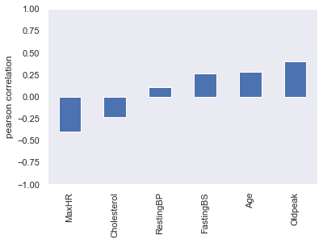

```python
## Graph the correlation chart
ax = correlations.plot(kind='bar')
ax.set(ylim=[-1, 1], ylabel='pearson correlation')
```

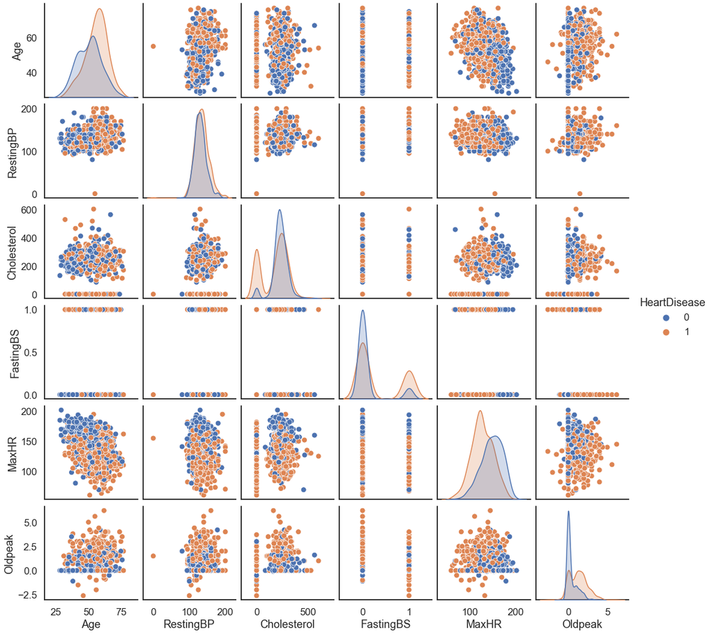

```python
sns.set_context('talk')
sns.set_style('white')
sns.pairplot(heart_df, hue='HeartDisease')
plt.show()
```

First Section Short Recap/Conclusion:

- 'Oldpeak' and 'MaxHR' was highly correlated with 'HeartDisease'.

### **Section 2: Simple Exploratory Data Analysis (EDA)**

```python
## check for unique variables on each features
heart_df.nunique()
```

```
Age                50
Sex                 2
ChestPainType       4
RestingBP          67
Cholesterol       222
FastingBS           2
RestingECG          3
MaxHR             119
ExerciseAngina      2
Oldpeak            53
ST_Slope            3
HeartDisease        2
dtype: int64
```

```python
## Take every fatures that have less than 5 uniques variable as categorical
## Take every fatures that have more than 4 uniques variable as numerical
## Excluding the HeartDisease columns
categorical_data_columns = heart_df.drop(
    columns='HeartDisease').dtypes[heart_df.nunique() < 5].index.tolist()
numerical_data_columns = heart_df.drop(
    columns='HeartDisease').dtypes[heart_df.nunique() > 4].index.tolist()
```

```python
## Checkout for each variables
print("Categorical Features: ", categorical_data_columns)
print("Numerical Features: ", numerical_data_columns)
```

```
Categorical Features:  ['Sex', 'ChestPainType', 'FastingBS', 'RestingECG', 'ExerciseAngina', 'ST_Slope']
Numerical Features:  ['Age', 'RestingBP', 'Cholesterol', 'MaxHR', 'Oldpeak']
```

#### **Categorical Data Columns EDA**

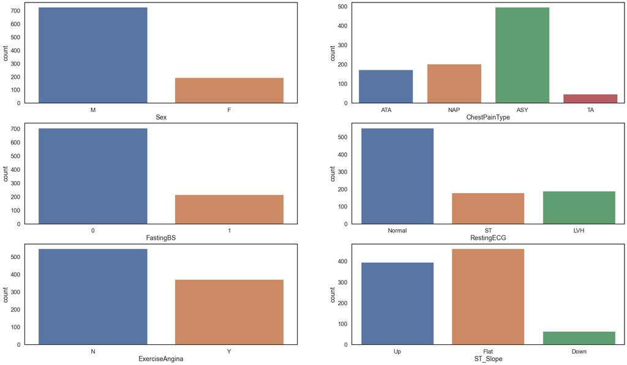

```python
## Visualize distributon for every categorical columns
plt.figure(figsize=(30, 30))
i = 1
for column in categorical_data_columns:
    plt.subplot(5, 2, i)
    sns.countplot(x=heart_df[column])
    i += 1
plt.show()
```

```python
## Calculate proportion of dominant classes in each category

num_rows = heart_df[categorical_data_columns].shape[0]
for i, cat in enumerate(heart_df[categorical_data_columns].columns):
    val_counts = heart_df[cat].value_counts()
    dominant_frac = val_counts.iloc[0] / num_rows
    print(
        f'`{val_counts.index[0]}` alone contributes to {round(dominant_frac * 100, 2)}% of {cat}')
```

```
`M` alone contributes to 78.98% of Sex
`ASY` alone contributes to 54.03% of ChestPainType
`0` alone contributes to 76.69% of FastingBS
`Normal` alone contributes to 60.13% of RestingECG
`N` alone contributes to 59.59% of ExerciseAngina
`Flat` alone contributes to 50.11% of ST_Slope
```

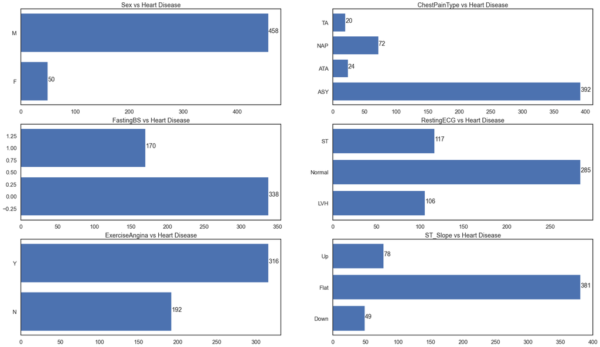

```python
## Visualize HeartDisease count for every categorical columns

plt.figure(figsize=(30, 30))
i = 1
for column in categorical_data_columns:
    type_count = heart_df.groupby(column)["HeartDisease"].sum()
    plt.subplot(5, 2, i)
    x = type_count.index
    y = type_count.values
    plt.barh(x, y)
    plt.title(f"{column} vs Heart Disease")
    for index, value in enumerate(y):
        plt.text(value, index,
                 value)
    i += 1
plt.show()
```

```python
## Calculate the percentage of HeartDisease
tuples = []
values = []
for x in categorical_data_columns:
    value_distribution = heart_df[x].value_counts().sort_index()
    stroke_count = heart_df.groupby(x)["HeartDisease"].sum().sort_index()
    for y in range(len(value_distribution)):
        ratio = round(
            (stroke_count.iloc[y] / value_distribution.iloc[y]) * 100, 2)
        #print("{}: {} percentage on stroke is {}%".format(x, stroke_count.index[y], ratio))
        ratio = str(ratio) + "%"
        tuples.append((x, stroke_count.index[y]))
        values.append(ratio)
```

```python
## Displaying the percentage in a table form
multicol1 = pd.MultiIndex.from_tuples(tuples)
df_percentage = pd.DataFrame([values],
                             index=['HeartDisease Percentage'],
                             columns=multicol1)

df_percentage.T
```

|  |  | HeartDisease Percentage |
| --- | --- | --- |
| Sex | F | 25.91% |
|  | M | 63.17% |
| ChestPainType | ASY | 79.03% |
|  | ATA | 13.87% |
|  | NAP | 35.47% |
|  | TA | 43.48% |
| FastingBS | 0 | 48.01% |
|  | 1 | 79.44% |
| RestingECG | LVH | 56.38% |
|  | Normal | 51.63% |
|  | ST | 65.73% |
| ExerciseAngina | N | 35.1% |
|  | Y | 85.18% |
| ST_Slope | Down | 77.78% |
|  | Flat | 82.83% |
|  | Up | 19.75% |

Categorical Data Columns EDA Short Recap/Conclusion:

- 'Male', 'Asymptomatic', 'Fasting Blood Sugar > 120 mg/dl', 'Having ST-T Wave Abnormality', 'Exercise-Induced Angina', and 'Flat Slope of the Peak Exercise ST Segment', have a high influence on causes of heart disease.

#### **Numerical Data Columns EDA**

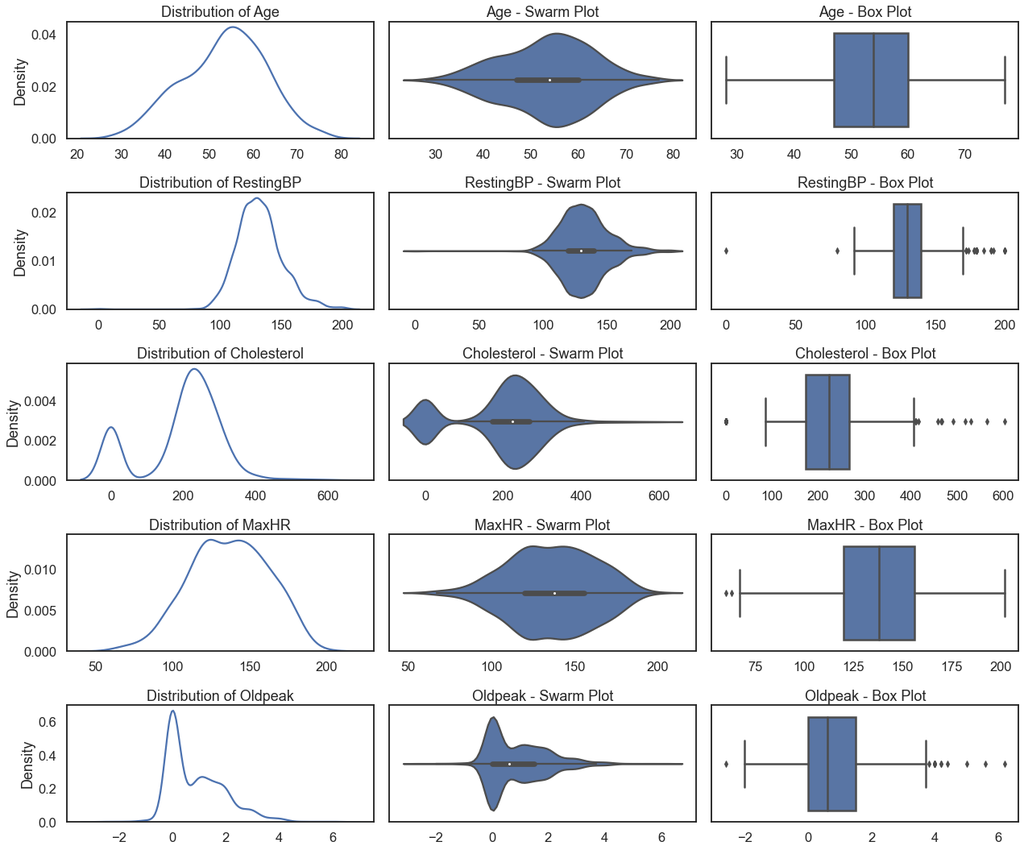

```python
## Visualize distribution on numerical features
rows = len(numerical_data_columns)
cols = 3

fig = plt.figure(1, (18, rows*3))

i = 0
for feature in numerical_data_columns:

    i += 1
    ax1 = plt.subplot(rows, cols, i)
    sns.kdeplot(data=heart_df, x=feature)
    ax1.set_xlabel(None)
    ax1.set_title(f'Distribution of {feature}')
    plt.tight_layout()

    i += 1
    ax2 = plt.subplot(rows, cols, i)
    sns.violinplot(data=heart_df, x=feature)
    ax2.set_xlabel(None)
    ax2.set_title(f'{feature} - Swarm Plot')
    plt.tight_layout()

    i += 1
    ax3 = plt.subplot(rows, cols, i)
    sns.boxplot(data=heart_df, x=feature, orient='h', linewidth=2.5)
    ax3.set_xlabel(None)
    ax3.set_title(f'{feature} - Box Plot')
    plt.tight_layout()

plt.show()
```

```python
## Find outliers using Tukey's method
def tukey_outliers(x):
    ## Tukey outliers are based on the boundaries defined by quantiles and IQR
    q1 = np.percentile(x, 25)
    q3 = np.percentile(x, 75)

    iqr = q3 - q1

    lower_boundary = q1 - (iqr * 1.5)
    upper_boundary = q3 + (iqr * 1.5)

    outliers = x[(x < lower_boundary) | (x > upper_boundary)]
    return outliers
```

```python
## Calculate the tukey outliers

outlier_dict = {}
for num_feature in numerical_data_columns:
    outliers = tukey_outliers(heart_df[num_feature])
    if len(outliers):
        print(f"-> {num_feature} has {len(outliers)} tukey outliers")
        outlier_dict[num_feature] = outliers
    else:
        print(f"-> {num_feature} doesn't have any tukey outliers.")
        outlier_dict[num_feature] = None
```

```
-> Age doesn't have any tukey outliers.
-> RestingBP has 28 tukey outliers
-> Cholesterol has 183 tukey outliers
-> MaxHR has 2 tukey outliers
-> Oldpeak has 16 tukey outliers
```

```python
## Show the percentage of outliers

for x in numerical_data_columns:
    if x == 'Age':
        continue
    outliers = heart_df.loc[outlier_dict[x].index]
    print("{} has {}% of outliers".format(
        x, round(len(outliers)/len(heart_df) * 100, 2)))
```

```
RestingBP has 3.05% of outliers
Cholesterol has 19.93% of outliers
MaxHR has 0.22% of outliers
Oldpeak has 1.74% of outliers
```

```python
skew_limit = 0  # define a limit above which we will log transform
skew_vals = heart_df[numerical_data_columns].skew()
```

```python
skew_cols = (skew_vals
             .sort_values(ascending=False)
             .to_frame()
             .rename(columns={0: 'Skew'})
             .query('abs(Skew) > {}'.format(skew_limit)))

skew_cols
```

|  | Skew |
| --- | --- |
| Oldpeak | 1.022872 |
| RestingBP | 0.179839 |
| MaxHR | -0.144359 |
| Age | -0.195933 |
| Cholesterol | -0.610086 |

Numerical Data Columns EDA Short Recap/Conclusion:

- 'Cholesterol' has the highest percentage of outliers with '19.93%'.
- 'Oldpeak' is the most skewed data with '1.022872' of skewness.

### **Section 3: Feature Engineering**

```python
heart_df_oe = heart_df.copy()
```

```python
## Create ordinal endocing mapper
sex_mapper = {
    'F':0,
    'M':1
    }
heart_df_oe['Sex'] = df['Sex'].replace(sex_mapper)

cpt_mapper = {
    'ASY': 3,
    'ATA': 0,
    'NAP': 1,
    'TA': 2
}
heart_df_oe['ChestPainType'] = df['ChestPainType'].replace(cpt_mapper)

re_mapper = {
    'LVH':1,
    'Normal':0,
    'ST':2
    }
heart_df_oe['RestingECG'] = df['RestingECG'].replace(re_mapper)

ea_mapper = {
    'N':0,
    'Y':1
    }
heart_df_oe['ExerciseAngina'] = df['ExerciseAngina'].replace(ea_mapper)

sts_mapper = {
    'Down':1,
    'Flat':2,
    'Up':0
    }
heart_df_oe['ST_Slope'] = df['ST_Slope'].replace(sts_mapper)
```

```python
heart_df_oe.head()
```

|  | Age | Sex | ChestPainType | RestingBP | Cholesterol | FastingBS | RestingECG | MaxHR | ExerciseAngina | Oldpeak | ST_Slope | HeartDisease |
| --- | --- | --- | --- | --- | --- | --- | --- | --- | --- | --- | --- | --- |
| 0 | 40 | 1 | 0 | 140 | 289 | 0 | 0 | 172 | 0 | 0.0 | 0 | 0 |
| 1 | 49 | 0 | 1 | 160 | 180 | 0 | 0 | 156 | 0 | 1.0 | 2 | 1 |
| 2 | 37 | 1 | 0 | 130 | 283 | 0 | 2 | 98 | 0 | 0.0 | 0 | 0 |
| 3 | 48 | 0 | 3 | 138 | 214 | 0 | 0 | 108 | 1 | 1.5 | 2 | 1 |
| 4 | 54 | 1 | 1 | 150 | 195 | 0 | 0 | 122 | 0 | 0.0 | 0 | 0 |

```python
## Check correlation between each features to target
y = (heart_df_oe['HeartDisease'] == 1).astype(int)
fields = list(heart_df_oe.columns[:-1])  # everything except "HeartDisease"
correlations = heart_df_oe[fields].corrwith(y)
correlations.sort_values(inplace=True)
correlations
```

```
MaxHR            -0.400421
Cholesterol      -0.232741
RestingBP         0.107589
RestingECG        0.107628
FastingBS         0.267291
Age               0.282039
Sex               0.305445
Oldpeak           0.403951
ExerciseAngina    0.494282
ChestPainType     0.536974
ST_Slope          0.607921
dtype: float64
```

```
[(-1.0, 1.0), Text(0, 0.5, 'pearson correlation')]
```

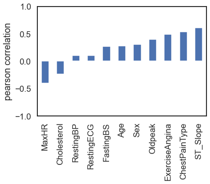

```python
## Graph the correlation chart
ax = correlations.plot(kind='bar')
ax.set(ylim=[-1, 1], ylabel='pearson correlation')
```

```python
heart_df_oe_ft = heart_df_oe.copy()
```

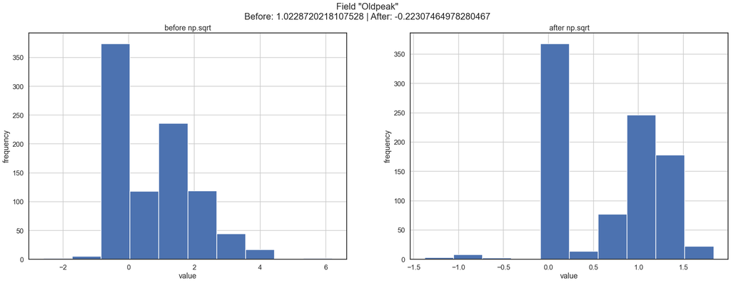

```python
## Create before-after tansformation graph
skew_features = ['Oldpeak']
for field in skew_features:
    # Create two "subplots" and a "figure" using matplotlib
    fig, (ax_before, ax_after) = plt.subplots(1, 2, figsize=(30, 10))

    # Create a histogram on the "ax_before" subplot
    heart_df_oe_ft[field].hist(ax=ax_before)

    after_skew = np.cbrt(heart_df_oe_ft[field])

    # Apply a log transformation (numpy syntax) to this column
    after_skew.hist(ax=ax_after)

    # Formatting of titles etc. for each subplot
    ax_before.set(title='before np.sqrt', ylabel='frequency', xlabel='value')
    ax_after.set(title='after np.sqrt', ylabel='frequency', xlabel='value')
    fig.suptitle('Field "{}"\nBefore: {} | After: {}\n'.format(
        field, heart_df_oe_ft[field].skew(), after_skew.skew()))
```

```python
## Apply transformation to the feature
heart_df_oe_ft['Oldpeak'] = np.cbrt(heart_df_oe_ft['Oldpeak'])
```

```python
heart_df_oe_ft.head()
```

|  | Age | Sex | ChestPainType | RestingBP | Cholesterol | FastingBS | RestingECG | MaxHR | ExerciseAngina | Oldpeak | ST_Slope | HeartDisease |
| --- | --- | --- | --- | --- | --- | --- | --- | --- | --- | --- | --- | --- |
| 0 | 40 | 1 | 0 | 140 | 289 | 0 | 0 | 172 | 0 | 0.000000 | 0 | 0 |
| 1 | 49 | 0 | 1 | 160 | 180 | 0 | 0 | 156 | 0 | 1.000000 | 2 | 1 |
| 2 | 37 | 1 | 0 | 130 | 283 | 0 | 2 | 98 | 0 | 0.000000 | 0 | 0 |
| 3 | 48 | 0 | 3 | 138 | 214 | 0 | 0 | 108 | 1 | 1.144714 | 2 | 1 |
| 4 | 54 | 1 | 1 | 150 | 195 | 0 | 0 | 122 | 0 | 0.000000 | 0 | 0 |

Feature Transformation Short Recap/Conclusion:

### **Section 4: Classification**

```python
heart_df['HeartDisease'].value_counts()
```

```
1    508
0    410
Name: HeartDisease, dtype: int64
```

The 'HeartDisease' count kind of slightly imbalanced, so we gonna focus more on Precision - Recall with 'F1 Score'

```python
## Split the Training and Test set with 'StratifiedShuffleSplit'
## It would be better to split-out this way for imbalanced dataset

from sklearn.model_selection import StratifiedShuffleSplit

feature_cols = [x for x in heart_df_oe_ft.columns if x != 'HeartDisease']

## Get the split indexes
strat_shuf_split = StratifiedShuffleSplit(n_splits=4,
                                          test_size=0.333,
                                          random_state=42)

train_idx, test_idx = next(strat_shuf_split.split(
    heart_df_oe_ft[feature_cols], heart_df_oe_ft['HeartDisease']))

## Create the dataframes
X_train = heart_df_oe_ft.loc[train_idx, feature_cols]
y_train = heart_df_oe_ft.loc[train_idx, 'HeartDisease']

X_test = heart_df_oe_ft.loc[test_idx, feature_cols]
y_test = heart_df_oe_ft.loc[test_idx, 'HeartDisease']
```

```python
## Import neccessary libraries for modelling

from sklearn.linear_model import LogisticRegression
from sklearn.neighbors import KNeighborsClassifier
from sklearn.svm import SVC
from sklearn.ensemble import RandomForestClassifier, GradientBoostingClassifier, VotingClassifier

from sklearn.preprocessing import MinMaxScaler, StandardScaler, FunctionTransformer
from sklearn.pipeline import make_pipeline, Pipeline
from sklearn.model_selection import GridSearchCV, cross_val_score
from sklearn.metrics import roc_curve, precision_recall_curve, confusion_matrix, roc_auc_score, classification_report

import datetime
```

```python
## Create list of scaler

dummyScaller = FunctionTransformer()

scalers = [
    (dummyScaller, "NoScaling"),
    (MinMaxScaler(), "MinMaxScaler"),
    (StandardScaler(), "StandardScaler")
]
```

```python
## Create list of models

models = [
    RandomForestClassifier(random_state=42),
    GradientBoostingClassifier(random_state=42),
    SVC(random_state=42),
    KNeighborsClassifier(),
    LogisticRegression(random_state=42, solver='liblinear')
]
```

```python
## Create list (dictionaries) for 'GridsearchCV'

search_space_dict = {}

search_space_dict['RandomForestClassifier'] = {
        'randomforestclassifier__n_estimators': range(10, 300, 50),
        'randomforestclassifier__max_depth': range(0, 100, 10),
        'randomforestclassifier__max_features': ["auto", "sqrt", "log2"],
        'randomforestclassifier__criterion': ['gini', 'entropy']
    }

search_space_dict['GradientBoostingClassifier'] = {
        'gradientboostingclassifier__n_estimators': range(10, 300, 50),
        'gradientboostingclassifier__learning_rate': [0.1, 0.01, 0.001, 0.0001],
        'gradientboostingclassifier__max_features': [1, 2, 3, 4],
        'gradientboostingclassifier__subsample': [1.0, 0.5]
    }

search_space_dict['SVC'] = {
        'svc__gamma': [0.1, 1, 10],
        'svc__C': [0.1, 1, 10],
        'svc__kernel': ['linear', 'rbf']
    }

search_space_dict['KNeighborsClassifier'] = {
        'kneighborsclassifier__weights': ['uniform', 'distance'],
        'kneighborsclassifier__n_neighbors': range(1, 50, 2)
    }

search_space_dict['LogisticRegression'] = {
        'logisticregression__penalty': ['l1', 'l2', 'elasticnet'],
        'logisticregression__C': [0.01, 0.1, 1, 10, 100]
    }
```

```python
## Create pipeline matrix

pipelines_matrix = {}

for scaler, scaler_desc in scalers:
    pipelines_matrix[scaler_desc] = {}
    print(scaler_desc)
    for model in models:
        print("            ", model.__class__.__name__)
        pipelines_matrix[scaler_desc][model.__class__.__name__] = make_pipeline(
            scaler, model)
```

```
NoScaling
             RandomForestClassifier
             GradientBoostingClassifier
             SVC
             KNeighborsClassifier
             LogisticRegression
MinMaxScaler
             RandomForestClassifier
             GradientBoostingClassifier
             SVC
             KNeighborsClassifier
             LogisticRegression
StandardScaler
             RandomForestClassifier
             GradientBoostingClassifier
             SVC
             KNeighborsClassifier
             LogisticRegression
```

```python
## Create a function for performing cross validation of all algorithms
## Fuction will return a dataframe with the result from each pipeline

def cross_validator(X_train, y_train, pipelines_matrix):
    i = 0
    for scaler in pipelines_matrix:
        print("----------------------", scaler)
        for model in pipelines_matrix[scaler]:
            i += 1
            print("     +++++++", model)
            startT = datetime.datetime.now()

            pipeline = pipelines_matrix[scaler][model]

            search_space = search_space_dict[model]
            clf = GridSearchCV(pipeline,
                               search_space,
                               scoring='f1',
                               cv = 4,
                               n_jobs=-1)
            clf.fit(X_train, y_train)

            print("          f1-scores: ", clf.best_score_)

            headers = ['scaler', 'model',
                       'f1', 'best_params']
            dfResultsTemp = pd.DataFrame(columns=headers)
            dfResultsTemp.loc[0] = [
                scaler, model, clf.best_score_, clf.best_params_]

            print("             exec time:", datetime.datetime.now() -
                  startT, datetime.datetime.now())

            if i == 1:
                data_concat = dfResultsTemp.copy()
            else:
                data_concat = pd.concat([data_concat, dfResultsTemp])

    return data_concat
```

```python
## Run the function

grid_search_df = cross_validator(X_train, y_train, pipelines_matrix)
```

```
---------------------- NoScaling
     +++++++ RandomForestClassifier
          f1-scores:  0.8788514944844867
             exec time: 0:00:22.346816 2022-01-26 00:54:05.537119
     +++++++ GradientBoostingClassifier
          f1-scores:  0.8843207891723295
             exec time: 0:00:05.244787 2022-01-26 00:54:10.782035
     +++++++ SVC
          f1-scores:  0.8735797133365211
             exec time: 0:00:25.667875 2022-01-26 00:54:36.450191
     +++++++ KNeighborsClassifier
          f1-scores:  0.7339716036042038
             exec time: 0:00:00.202430 2022-01-26 00:54:36.652869
     +++++++ LogisticRegression
          f1-scores:  0.8710166857990979
             exec time: 0:00:00.063671 2022-01-26 00:54:36.716746
---------------------- MinMaxScaler
     +++++++ RandomForestClassifier
          f1-scores:  0.8788514944844867
             exec time: 0:00:22.647035 2022-01-26 00:54:59.364002
     +++++++ GradientBoostingClassifier
          f1-scores:  0.8843207891723295
             exec time: 0:00:05.436807 2022-01-26 00:55:04.801025
     +++++++ SVC
          f1-scores:  0.882691527612817
             exec time: 0:00:00.115919 2022-01-26 00:55:04.917157
     +++++++ KNeighborsClassifier
          f1-scores:  0.8787522968881352
             exec time: 0:00:00.211279 2022-01-26 00:55:05.128697
     +++++++ LogisticRegression
          f1-scores:  0.8710623742321698
             exec time: 0:00:00.059883 2022-01-26 00:55:05.188811
---------------------- StandardScaler
     +++++++ RandomForestClassifier
          f1-scores:  0.8788514944844867
             exec time: 0:00:22.861337 2022-01-26 00:55:28.050370
     +++++++ GradientBoostingClassifier
          f1-scores:  0.8830829297169877
             exec time: 0:00:05.419634 2022-01-26 00:55:33.470217
     +++++++ SVC
          f1-scores:  0.8805231575388777
             exec time: 0:00:00.154154 2022-01-26 00:55:33.624588
     +++++++ KNeighborsClassifier
          f1-scores:  0.8861955559141458
             exec time: 0:00:00.199574 2022-01-26 00:55:33.824371
     +++++++ LogisticRegression
          f1-scores:  0.8713864394170808
             exec time: 0:00:00.052167 2022-01-26 00:55:33.876755
```

```python
## Display the result

grid_search_df.sort_values(by=['f1'], ascending=False, ignore_index=True)
```

|  | scaler | model | f1 | best_params |
| --- | --- | --- | --- | --- |
| 0 | StandardScaler | KNeighborsClassifier | 0.886196 | {'kneighborsclassifier__n_neighbors': 15, 'kne... |
| 1 | NoScaling | GradientBoostingClassifier | 0.884321 | {'gradientboostingclassifier__learning_rate': ... |
| 2 | MinMaxScaler | GradientBoostingClassifier | 0.884321 | {'gradientboostingclassifier__learning_rate': ... |
| 3 | StandardScaler | GradientBoostingClassifier | 0.883083 | {'gradientboostingclassifier__learning_rate': ... |
| 4 | MinMaxScaler | SVC | 0.882692 | {'svc__C': 1, 'svc__gamma': 1, 'svc__kernel': ... |
| 5 | StandardScaler | SVC | 0.880523 | {'svc__C': 1, 'svc__gamma': 0.1, 'svc__kernel'... |
| 6 | NoScaling | RandomForestClassifier | 0.878851 | {'randomforestclassifier__criterion': 'entropy... |
| 7 | MinMaxScaler | RandomForestClassifier | 0.878851 | {'randomforestclassifier__criterion': 'entropy... |
| 8 | StandardScaler | RandomForestClassifier | 0.878851 | {'randomforestclassifier__criterion': 'entropy... |
| 9 | MinMaxScaler | KNeighborsClassifier | 0.878752 | {'kneighborsclassifier__n_neighbors': 15, 'kne... |
| 10 | NoScaling | SVC | 0.873580 | {'svc__C': 1, 'svc__gamma': 0.1, 'svc__kernel'... |
| 11 | StandardScaler | LogisticRegression | 0.871386 | {'logisticregression__C': 0.1, 'logisticregres... |
| 12 | MinMaxScaler | LogisticRegression | 0.871062 | {'logisticregression__C': 0.1, 'logisticregres... |
| 13 | NoScaling | LogisticRegression | 0.871017 | {'logisticregression__C': 1, 'logisticregressi... |
| 14 | NoScaling | KNeighborsClassifier | 0.733972 | {'kneighborsclassifier__n_neighbors': 39, 'kne... |

```python
## Create a csv file for future evaluation

grid_search_df.sort_values(
    by=['f1'], ascending=False, ignore_index=True).to_csv('model_evaluation_heart_disease_280122.csv', index=False)
```

Grid Search CV Evaluation Short Recap/Conclusion:

- 'KNeighborsClassifier' with 'StandardScaler' have the highest F1 score with '0.886196'.
- 'GradientBoostingClassifier' following on number 2 with identical F1 Weighted score (between 'NoScalling' and 'MinMaxScaler') with '0.884321'.
- We gonna take 'GradientBoostingClassifier' and 'KNeighborsClassifier' for futher analysis.

```python
## Recreate model list with top models only

top_models = [
    ['K Neighbors Classifier', KNeighborsClassifier(n_neighbors=15, weights='uniform')],
    ['Gradient Boosting Classifier', GradientBoostingClassifier(learning_rate=0.01, max_features=3, n_estimators=110,
                                                                random_state=42, subsample=0.5)]
]
```

```python
##  Create a report dataframe for Classification Reports and Confussion Matrix

def report_dataframe(m):
    pipeline = Pipeline(steps=[
        ('scaler', StandardScaler()),
        ('model', m[1])])

    pipeline.fit(X_train, y_train)

    y_pred = pipeline.predict(X_test)

    print(m[0] + " with StandardScaler Reports: ")

    cr = classification_report(y_test, y_pred)
    cm = confusion_matrix(y_test, y_pred)
    print(cm)
    print(cr)
```

```python
for m in range(len(top_models)):
    report_dataframe(top_models[m])
```

```
K Neighbors Classifier with StandardScaler Reports:
[[117  20]
 [ 15 154]]
              precision    recall  f1-score   support

           0       0.89      0.85      0.87       137
           1       0.89      0.91      0.90       169

    accuracy                           0.89       306
   macro avg       0.89      0.88      0.88       306
weighted avg       0.89      0.89      0.89       306

Gradient Boosting Classifier with StandardScaler Reports:
[[117  20]
 [ 11 158]]
              precision    recall  f1-score   support

           0       0.91      0.85      0.88       137
           1       0.89      0.93      0.91       169

    accuracy                           0.90       306
   macro avg       0.90      0.89      0.90       306
weighted avg       0.90      0.90      0.90       306
```

It might be nice to create a 'VotingClassifier' between those top models, most likely will improve the final model as well.

```python
## Create a Voting Classifier pipeline
## Next steps is to fit, get Classification Report, and Confussion Matrix

voting_classifier_pipeline = Pipeline(steps=[
    ('data_scaling', StandardScaler()),
    ('model', VotingClassifier(top_models, voting='soft'))])
```

```python
voting_classifier_pipeline.fit(X_train, y_train)
```

```
Pipeline(steps=[('data_scaling', StandardScaler()),
                ('model',
                 VotingClassifier(estimators=[['K Neighbors Classifier',
                                               KNeighborsClassifier(n_neighbors=15)],
                                              ['Gradient Boosting Classifier',
                                               GradientBoostingClassifier(learning_rate=0.01,
                                                                          max_features=3,
                                                                          n_estimators=110,
                                                                          random_state=42,
                                                                          subsample=0.5)]],
                                  voting='soft'))])
```

```python
y_pred = voting_classifier_pipeline.predict(X_test)

print("Voting Classifier" + " with " + "StandardScaler" + " Reports: ")

cr = classification_report(y_test, y_pred)
cm = confusion_matrix(y_test, y_pred)
print(cm)
print(cr)
```

```
Voting Classifier with StandardScaler Reports:
[[117  20]
 [ 12 157]]
              precision    recall  f1-score   support

           0       0.91      0.85      0.88       137
           1       0.89      0.93      0.91       169

    accuracy                           0.90       306
   macro avg       0.90      0.89      0.89       306
weighted avg       0.90      0.90      0.90       306
```

Next steps is to create a graph for ROC and Precision - Recall curve and Feature Importances

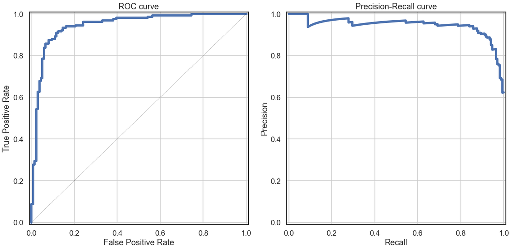

```python
## Create a graph for ROC and Precision - Recall curve

sns.set_context('talk')

fig, axList = plt.subplots(ncols=2)
fig.set_size_inches(16, 8)

# Get the probabilities for each of the two categories
y_prob = voting_classifier_pipeline.predict_proba(X_test)

# Plot the ROC-AUC curve
ax = axList[0]

fpr, tpr, thresholds = roc_curve(y_test, y_prob[:, 1])
ax.plot(fpr, tpr, linewidth=5)
# It is customary to draw a diagonal dotted line in ROC plots.
# This is to indicate completely random prediction. Deviation from this
# dotted line towards the upper left corner signifies the power of the model.
ax.plot([0, 1], [0, 1], ls='--', color='black', lw=.3)
ax.set(xlabel='False Positive Rate',
       ylabel='True Positive Rate',
       xlim=[-.01, 1.01], ylim=[-.01, 1.01],
       title='ROC curve')
ax.grid(True)

# Plot the precision-recall curve
ax = axList[1]

precision, recall, _ = precision_recall_curve(y_test, y_prob[:, 1])
ax.plot(recall, precision, linewidth=5)
ax.set(xlabel='Recall', ylabel='Precision',
       xlim=[-.01, 1.01], ylim=[-.01, 1.01],
       title='Precision-Recall curve')
ax.grid(True)

plt.tight_layout()
```

```
[Text(0, 0.5, 'Feature')]
```

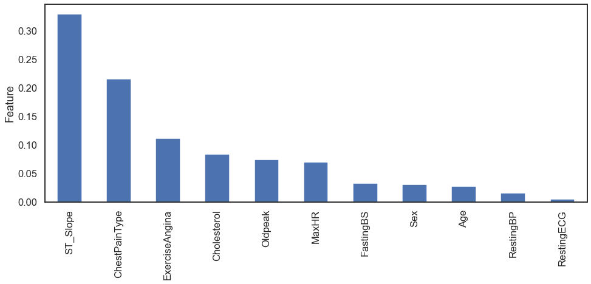

```python
## Create a graph for Feature Importance (Gradient Boosting Classifier)

feature_imp = pd.Series(voting_classifier_pipeline.named_steps['model'].named_estimators['Gradient Boosting Classifier'].feature_importances_,
                        index=feature_cols).sort_values(ascending=False)

ax = feature_imp.plot(kind='bar', figsize=(16, 6))
ax.set(ylabel='Relative Importance')
ax.set(ylabel='Feature')
```

Final Model Evaluation Short Recap/Conclusion:

- There's no improvement with 'VotingClassifier'.
- ROC - AUC and Precision - Recall curve seems pretty well.
- As shown from previous pearson correlation, 'ST_slope' and 'ChestPainType' was proven to be highly impactful to model estimation.

**2022 | Dimas Adrian Mukti / [@berodimas](https://berodimas.netlify.app/)**